# Practica3

Autor

2022-10-06

## Árboles de decisiones

#### Ilustraremos esta práctica con datos del conjunto Iris.

```r
# Cargando los datos. Editar la ubicación del archivo de datos en su computadora
mydata<-read.table("/home/rosa/Documents/MDD2022/data/iris.data", header = T, sep = ",")
```

Creación de un árbol usando todos los datos Iris.

```r
library(tree)
mydata.tree<-tree(Especie ~.,mydata)

mydata.tree
```

```
## node), split, n, deviance, yval, (yprob)
##       * denotes terminal node
##
##  1) root 150 329.600 Iris-setosa ( 0.33333 0.33333 0.33333 )
##    2) Petalo.Longitud < 2.45 50   0.000 Iris-setosa ( 1.00000 0.00000 0.00000 ) *
##    3) Petalo.Longitud > 2.45 100 138.600 Iris-versicolor ( 0.00000 0.50000 0.50000 )
##      6) Petalo.Ancho < 1.75 54  33.320 Iris-versicolor ( 0.00000 0.90741 0.09259 )
##       12) Petalo.Longitud < 4.95 48   9.721 Iris-versicolor ( 0.00000 0.97917 0.02083 )
##         24) Sepalo.Longitud < 5.15 5   5.004 Iris-versicolor ( 0.00000 0.80000 0.20000 ) *
##         25) Sepalo.Longitud > 5.15 43   0.000 Iris-versicolor ( 0.00000 1.00000 0.00000 ) *
##       13) Petalo.Longitud > 4.95 6   7.638 Iris-virginica ( 0.00000 0.33333 0.66667 ) *
##      7) Petalo.Ancho > 1.75 46   9.635 Iris-virginica ( 0.00000 0.02174 0.97826 )
##       14) Petalo.Longitud < 4.95 6   5.407 Iris-virginica ( 0.00000 0.16667 0.83333 ) *
##       15) Petalo.Longitud > 4.95 40   0.000 Iris-virginica ( 0.00000 0.00000 1.00000 ) *
```

Resúmen del árbol creado con todos los datos del conjunto Iris

```r
summary(mydata.tree)
```

```
##
## Classification tree:
## tree(formula = Especie ~ ., data = mydata)
## Variables actually used in tree construction:
## [1] "Petalo.Longitud" "Petalo.Ancho"    "Sepalo.Longitud"
## Number of terminal nodes:  6
## Residual mean deviance:  0.1253 = 18.05 / 144
## Misclassification error rate: 0.02667 = 4 / 150
```

La función sencilla `plot` puede crear el diagram del árbol

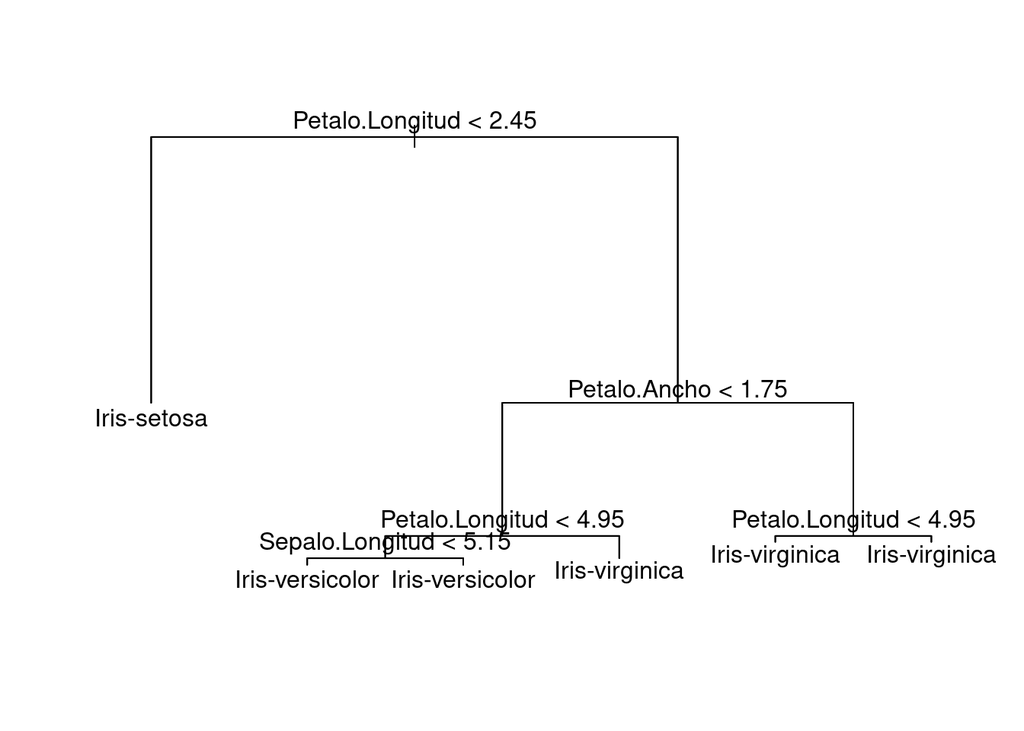

```r
# Ejecutar las dos lineas siguientes para crear el diagrama completo
plot(mydata.tree)
text(mydata.tree, pretty = 1)
```

#### Contruyendo árboles de decisión en fases de entrenamiento y evaluación

Incluimos funciones de los paquetes `caret` y `rpart.plot`.

```r
library(caret)
```

```r
install.packages("rpart.plot")
library(rpart.plot)
```

Estructura de los datos

```r
str(mydata)
```

```
## 'data.frame':    150 obs. of  5 variables:
##  $ Sepalo.Longitud: num  5.1 4.9 4.7 4.6 5 5.4 4.6 5 4.4 4.9 ...
##  $ Sepalo.Ancho   : num  3.5 3 3.2 3.1 3.6 3.9 3.4 3.4 2.9 3.1 ...
##  $ Petalo.Longitud: num  1.4 1.4 1.3 1.5 1.4 1.7 1.4 1.5 1.4 1.5 ...
##  $ Petalo.Ancho   : num  0.2 0.2 0.2 0.2 0.2 0.4 0.3 0.2 0.2 0.1 ...
##  $ Especie        : Factor w/ 3 levels "Iris-setosa",..: 1 1 1 1 1 1 1 1 1 1 ...
```

Dado que estamos usando un clasificador basado en árboles, no hay necesidad de escalar el conjunto de datos.

En este ejemplo, dividimos el conjunto de datos en conjuntos de entrenamiento y prueba, con el 70 % de los datos en entrenamiento y el 30 % en prueba

```r
set.seed(3033) # escogemos una semilla
intrain <- createDataPartition(y = mydata$Especie, p= 0.7, list = FALSE)
training <- mydata[intrain,]
testing <- mydata[-intrain,]
dim(training)
```

```
## [1] 105   5
```

```r
dim(testing)
```

```
## [1] 45  5
```

#### *Clasificación por ganancia de información (entropía)*

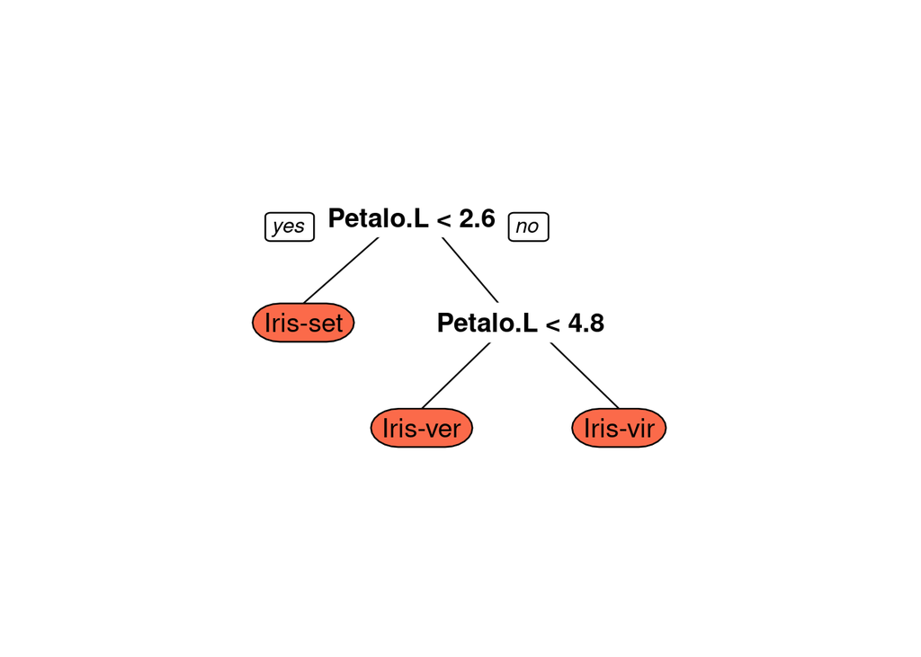

```r
#Fase de entrenamiento
trctrl <- trainControl(method = "repeatedcv", number = 10, repeats = 3)
set.seed(3333)
dtree_fit_info <- train(Especie ~., data = training, method = "rpart",
                    parms = list(split = "information"),
                    trControl=trctrl,
                    tuneLength = 10)


prp(dtree_fit_info$finalModel, box.palette="Reds", tweak=1.2)
```

Ahora usamos el árbol aprendido para predecir en el conjunto de datos de evaluación o prueba (testing). Verificamos el desempeño con la matriz de confusión.

```r
#Fase de evaluación
test_pred_info<-predict(dtree_fit_info,newdata = testing)
confusionMatrix(test_pred_info,testing$Especie)
```

```
## Confusion Matrix and Statistics
##
##                  Reference
## Prediction        Iris-setosa Iris-versicolor Iris-virginica
##   Iris-setosa              15               0              0
##   Iris-versicolor           0              13              1
##   Iris-virginica            0               2             14
##
## Overall Statistics
##
##                Accuracy : 0.9333
##                  95% CI : (0.8173, 0.986)
##     No Information Rate : 0.3333
##     P-Value [Acc > NIR] : < 2.2e-16
##
##                   Kappa : 0.9
##
##  Mcnemar's Test P-Value : NA
##
## Statistics by Class:
##
##                      Class: Iris-setosa Class: Iris-versicolor
## Sensitivity                      1.0000                 0.8667
## Specificity                      1.0000                 0.9667
## Pos Pred Value                   1.0000                 0.9286
## Neg Pred Value                   1.0000                 0.9355
## Prevalence                       0.3333                 0.3333
## Detection Rate                   0.3333                 0.2889
## Detection Prevalence             0.3333                 0.3111
## Balanced Accuracy                1.0000                 0.9167
##                      Class: Iris-virginica
## Sensitivity                         0.9333
## Specificity                         0.9333
## Pos Pred Value                      0.8750
## Neg Pred Value                      0.9655
## Prevalence                          0.3333
## Detection Rate                      0.3111
## Detection Prevalence                0.3556
## Balanced Accuracy                   0.9333
```

El modelo de ganancia de información funcionó bien con una precisión de 0.93

A continuación realizamos el mismo procedimiento de aprender el model y evaluarlo utilizando el índice de Gini.

#### *Clasificación usando el índice de Gini*

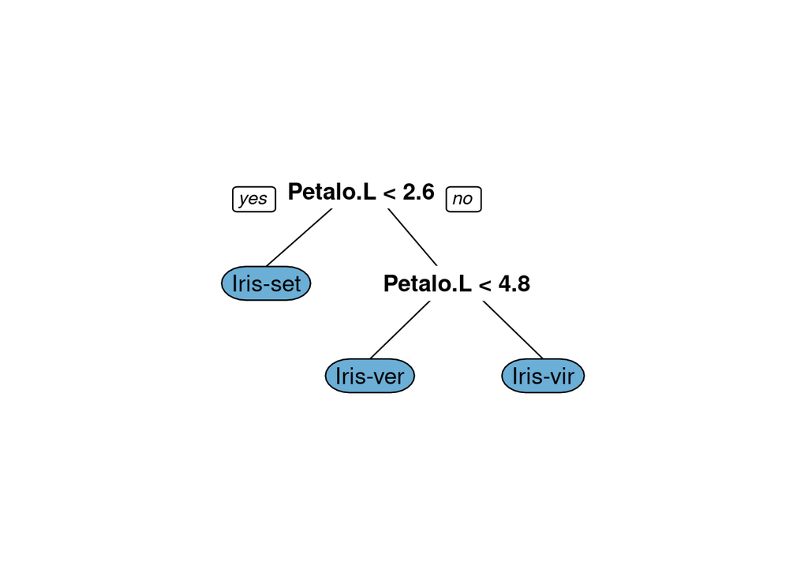

```r
# Fase de entrenamiento
set.seed(3333)
dtree_fit_gini <- train(Especie ~., data = training, method = "rpart",
                         parms = list(split = "gini"),
                         trControl=trctrl,
                         tuneLength = 10)
prp(dtree_fit_gini$finalModel,box.palette = "Blues", tweak = 1.2)
```

```r
# Fase de evaluación
test_pred_gini<-predict(dtree_fit_gini,newdata = testing)
confusionMatrix(test_pred_gini,testing$Especie)
```

```
## Confusion Matrix and Statistics
##
##                  Reference
## Prediction        Iris-setosa Iris-versicolor Iris-virginica
##   Iris-setosa              15               0              0
##   Iris-versicolor           0              13              1
##   Iris-virginica            0               2             14
##
## Overall Statistics
##
##                Accuracy : 0.9333
##                  95% CI : (0.8173, 0.986)
##     No Information Rate : 0.3333
##     P-Value [Acc > NIR] : < 2.2e-16
##
##                   Kappa : 0.9
##
##  Mcnemar's Test P-Value : NA
##
## Statistics by Class:
##
##                      Class: Iris-setosa Class: Iris-versicolor
## Sensitivity                      1.0000                 0.8667
## Specificity                      1.0000                 0.9667
## Pos Pred Value                   1.0000                 0.9286
## Neg Pred Value                   1.0000                 0.9355
## Prevalence                       0.3333                 0.3333
## Detection Rate                   0.3333                 0.2889
## Detection Prevalence             0.3333                 0.3111
## Balanced Accuracy                1.0000                 0.9167
##                      Class: Iris-virginica
## Sensitivity                         0.9333
## Specificity                         0.9333
## Pos Pred Value                      0.8750
## Neg Pred Value                      0.9655
## Prevalence                          0.3333
## Detection Rate                      0.3111
## Detection Prevalence                0.3556
## Balanced Accuracy                   0.9333
```

El modelo usando el índice de Gini funcionó bien con una precisión de 0.93